# Informe

#### **OBJETIVO 2**

**Describir los aspectos sociales y económicos de los egresados universitarios en el Perú, 2014.**

**1.Primer sueldo**

```
##    Length     Class      Mode
##     10564 character character
```

Tabla de información

```
##
## 1001 a 1500 1501 a 2500 2501 a 3500 3501 a 4500 4501 a 5500 5501 a 6500
##        1393         623         172          59          12           6
##  751 a 1000   Hasta 750 Más de 6500        <NA>
##        1524        1725           5        5045
```

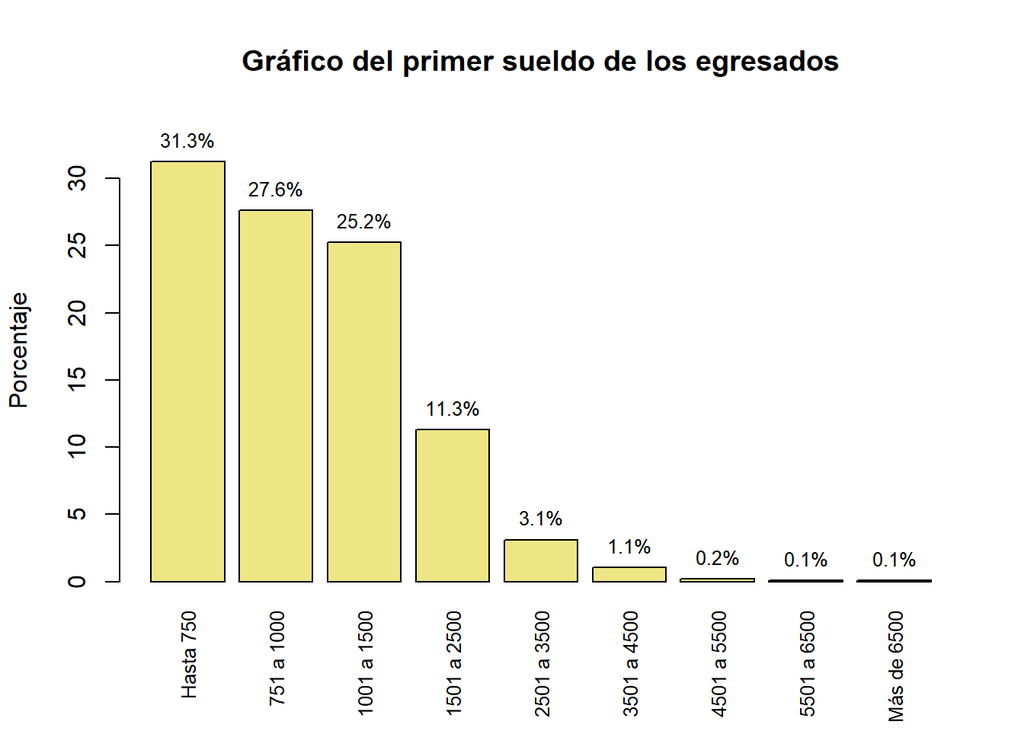

En la gráfica se observa que el 31.3% de los egresados han llegado a ganar hasta 750 soles; además, poco más de la mitad (52.8%) gana entre 751 y 1500 soles. Por el otro lado, menos del 0.5% tuvo un sueldo igual o mayor a 4501 soles. Se aprecia una clara caída de la cantidad de egresados con respecto a aumentar el sueldo, esto se debe a que el primer trabajo por falta de experiencia no tiene muchas ganancias económicas por lo que los egresados ganan lo mínimo e incluso menos.

**2.INGRESO OCUPACIÓN DEPENDIENTE**

```
##    Min. 1st Qu.  Median    Mean 3rd Qu.    Max.
##       0     300    1300    1462    2010   10500
```

Se tiene como ingreso mínimo la cantidad de 0 soles, por lo que hay egresados que aún no trabajan; por otro lado, la mayor cantidad recibida mensualmente fue de 10500 soles. En promedio un egresado podría ganar un total de 1462 soles, y la mitad de todos estos gana entre 300 y 2010 soles.

```
## [1]     0 10500
```

```
## [1] 10500
```

```
## [1] 1318.24
```

```
## [1] 0.9
```

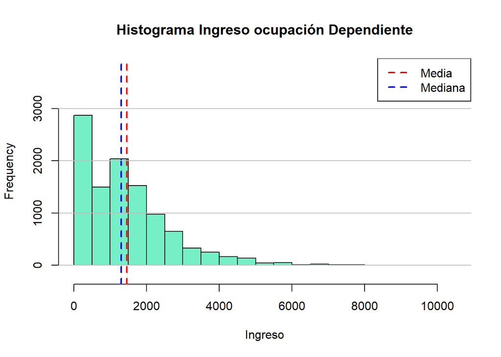

**3.Ingreso ocupación Dependiente V.S Etnia**

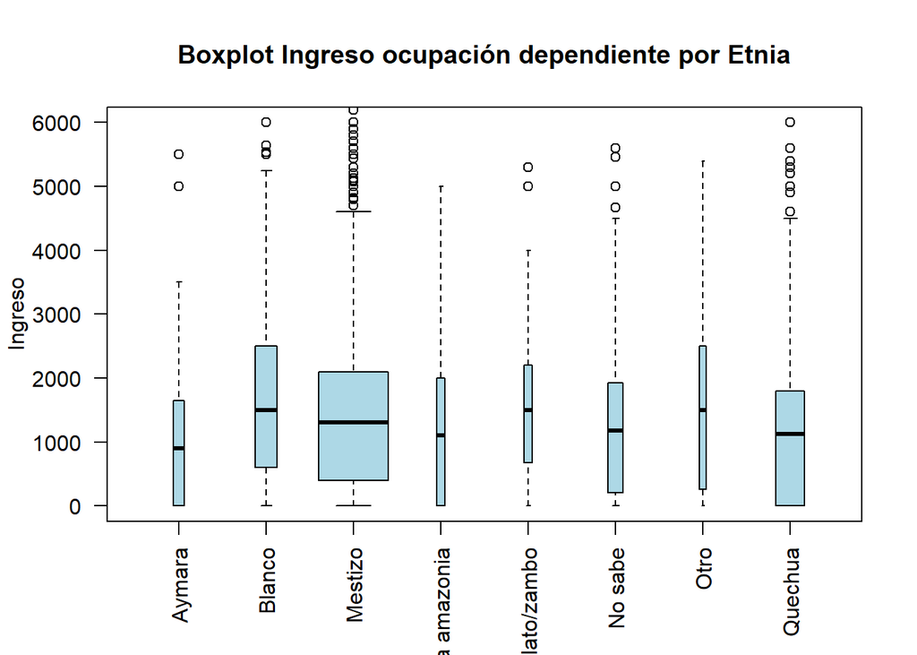

#### **OBJETIVO 3**

**Conocer la situación laboral de los egresados en el Perú en el año 2014 de acuerdo con la demanda de su carrera profesional.**

**1 carreras más escogida por los egresados**

Creación de los vectores y la grafica

```
##  [1] 14.80 13.41 13.13 11.19 10.37  8.50  8.41  8.02  7.38  4.79
```

[figure not shown]

**2. Ingreso V.S Carrera**

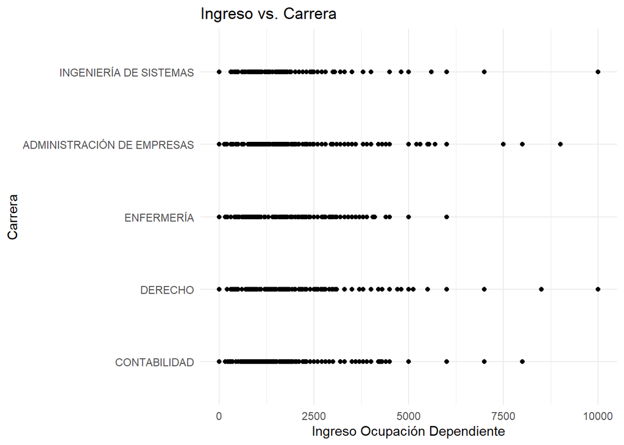

**3.Mérito V.S tiempo que demoro en conseguir trabajo**

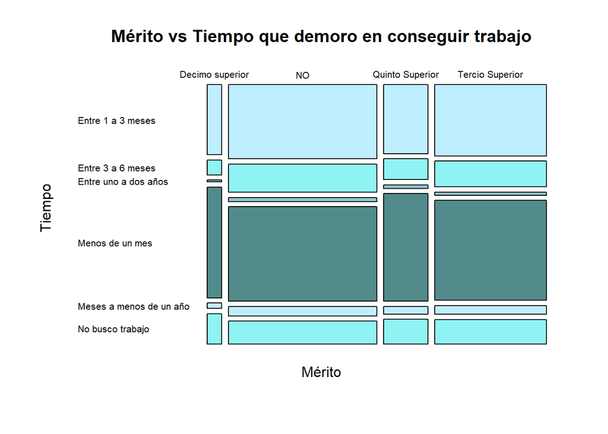

#### **OBJETIVO 4**

**9.Tiempo que demoran los egresados en conseguir trabajo**

```
##    Length     Class      Mode
##     10564 character character
```

Tabla de información

```
##
##       Entre 1 a 3 meses       Entre 3 a 6 meses    Entre uno a dos años
##                    1710                     609                      86
##         Menos de un mes Meses a menos de un año        No busco trabajo
##                    2343                     210                     573
##                    <NA>
##                    5033
```

Construcción de una tabla de frecuencia y la gráfica

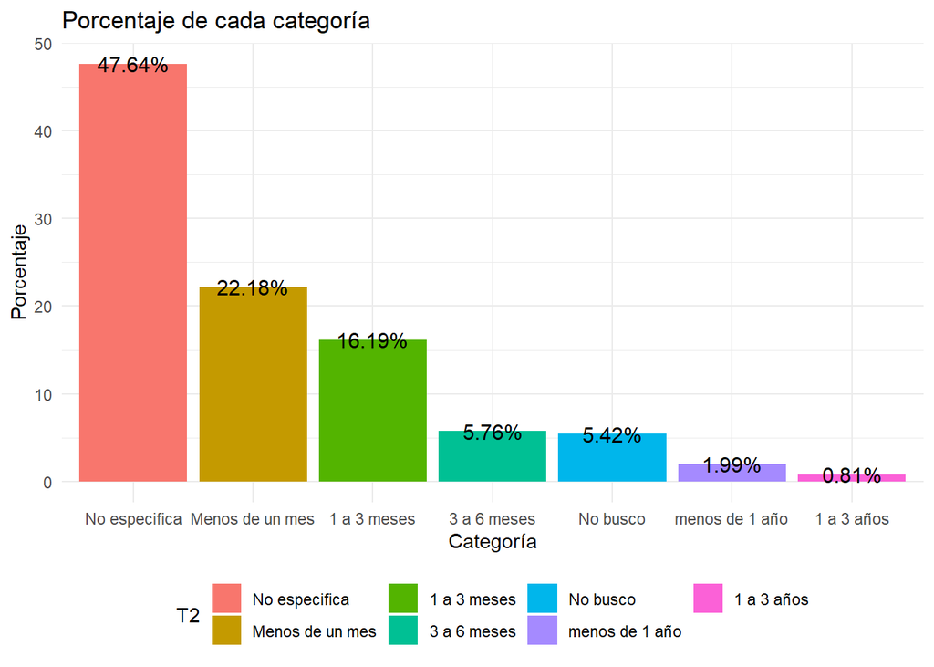

**Conclusiones del objetivo 4:**  
El tiempo demoran los egresados en conseguir su primer trabajo hay que tener en cuenta la existencia de un sesgo de muestreo por no especificar el tiempo o por no buscar trabajo. Estos datos suponen una gran cantidad pues de los que no se sabe respuesta es más de la mitad de observaciones (53.06%). Con los datos que posibles de utilizar que es un 46.94%, ahora lo analizaremos como un 100%, se puede calcular que los egresados que buscan trabajo después de terminar la carrera tienden a conseguir trabajo en el menor tiempo posible, pues los de menos de un mes conforman casi la mitad (47.25%), los de 1 a 3 meses son el otro grupo más numeroso representando el 34.49%.

# **4. ANÁLISIS PROBABILÍSTICO**

En el análisis probabilístico, se examinan las diferentes posibles ocurrencias de un evento y se asignan probabilidades a cada una de ellas.

## **4.1 Probabilidades Empíricas**

### **1.Variable Empleabilidad (Tiene trabajo o no)**

Según nos informa la INEI muchos de los egresados no tienen un trabajo fijo, la cual se puede ver la información en la siguiente tabla.

| Trabaja | Freq |
| --- | --- |
| No | 2179 |
| Sí | 8385 |

**EXPERIMENTO ALEATORIO:**Seleccionar un egresado del total de encuestados por la INEI en el año 2014 y observar la empleabilidad de los egresados.

**ESPACIO MUESTRAL(Ω)**
$$Ω=({Sí, No})$$
Sí=A1
No=A2

**Formula asociada a cada evento**

$$P(A)=\frac{n(A)}{n}$$
**Donde:**
n:total de la población
A:Evento asociado

Probabilidad de que un egresado cuente con empleo.
$$P(A1)=\frac{8385}{10564}=0.79$$
probabilidad de que un egresados no este empleado

$$P(A2)=\frac{2179}{10564}=0.21$$

### **2. Variable Tiempo que demoro conseguir trabajo**

Experimento aleatorio: Se encuesta a egresados universitarios del Perú según su tiempo que demoro conseguir trabajo y se registra los resultados.

Se establece el espacio muestral de Tiempo que demoro conseguir trabajo de acuerdo a la INEI
$$Ω={(No
especifica,No busco trabajo,Menos de un mes, Entre 1 a 3 meses, Entre 3
a 6 meses, Meses a menos de un año,Entre uno a dos años)}$$

```
##
##       Entre 1 a 3 meses       Entre 3 a 6 meses    Entre uno a dos años
##                    1710                     609                      86
##         Menos de un mes Meses a menos de un año        No busco trabajo
##                    2343                     210                     573
##                    <NA>
##                    5033
```

PROBABILIDAD DE QUE UN EGRESADO NO BUSCA TRABAJO

```
## [1] 0.05
```

PROBABILIDAD DE QUE UN EGRESADO CONSIGUE TRABAJO EN MENOS DE UN MES

```
## [1] 0.22
```

PROBABILIDAD DE QUE UN EGRESADO CONSIGUE TRABAJO ENTRE 1 A 3 MESES

```
## [1] 0.16
```

PROBABILIDAD DE QUE UN EGRESADO CONSIGUE TRABAJO ENTRE 3 A 6 MESES

```
## [1] 0.06
```

PROBABILIDAD DE QUE UN EGRESADO CONSIGUE TRABAJO ENTRE 6 A 12 MESES

```
## [1] 0.02
```

PROBABILIDAD DE QUE UN EGRESADO CONSIGUE TRABAJO ENTRE UNO A DOS AÑOS

```
## [1] 0.01
```

### **3.Trabajo depende de su carrera profesional**

**Experimento aleatorio:** Se encuesta a egresados universitarios del Perú según su trabajo depende de su carrera profesional y se registra los resultados.

Se establece el espacio muestral de Tiempo que demoro conseguir trabajo de acuerdo por INEI.
$$Ω=(No, No
espeficifica, Sí)$$

PROBABILIDAD DE QUE UN EGRESADO SU TRABAJO NO DEPENDA DE SU CARRERA PROFESIONAL

```
## [1] 0.13
```

PROBABILIDAD DE QUE UN EGRESADO SU TRABAJO SI DEPENDA DE SU CARRERA PROFESIONAL

```
## [1] 0.75
```

## **4.2 Probabilidades Condicionales**

### 1 Carrera/ Primer Sueldo=====Dependiente

¿Cuál es la probabilidad de que un egresado tenga un primer sueldo mayor a los S/. 1000 si eligió la carrera de contabilidad?

Experimento de probabilidad condicional por tener dos eventos donde nos piden hallar la probabilidad del evento A (que el primer sueldo sea mayor a 1000 soles) dado el evento B (que la carrera elegida haya sido).
**fórmula de probabilidad:**
$$P(A|B)=P(A∩B)/P(B)$$
Primero sacar probabilidad empírica de los 2 eventos, con el total de cada evento y dividir con el espacio muestral

Espacios muestrales:

Primer sueldo (todos los datos)

```
##
## 1001 a 1500 1501 a 2500 2501 a 3500 3501 a 4500 4501 a 5500 5501 a 6500
##        1393         623         172          59          12           6
##  751 a 1000   Hasta 750 Más de 6500        <NA>
##        1524        1725           5        5045
```

Probabilidades:

```
## [1] 10564
```

```
## [1] 618
```

```
## [1] 0.05850057
```

Se puede ver que la probabilidad que los egresados hayan eligido estudiar la carrera de contabilidad (B) es del 5.85%

```
## [1] 0.4113064
```

En el caso de que el primer sueldo sea mayor a mil soles (A) hay un 41.13%. Cabe aclarar que se hará el conteo de los eventos que sí han respondido los egresados.

Ya sabiendo cada probabilidad empírica hay que encontrar intercepción de ambos eventos (A∩B)

```
## [1] 114
```

```
## [1] 0.02065592
```

Se puede observar un 2.07% de probabilidad de que se den los dos eventos en el mismo caso (un egresado que gane mas de mil y estudie contabilidad)

Ya sabiendo lo anterior se puede usar la fórmula mostrada

```
## [1] 0.02065592
```

```
## [1] 0.05850057
```

```
## [1] 0.3530892
```

Respondiendo a la pregunta, la probabilidad de que un egresado gane en su primer sueldo sea mayor a S/.1000 si estudio contabilidad es del 35.31%

Para saber si estos dos eventos son independiente o dependiente entre si se emplea la fórmula: P(A∩B)=P(A)*P(B) Si esta se cumple entonces serán independiente y caso contrario serán dependiente

```
## [1] 0.02065592
```

```
## [1] 0.02406166
```

```
## [1] 14.15423
```

Se puede ver que hay una diferencia entre los dos resultados del 14.15%, por lo que se puede encontrar una ligera dependencia del evento dicho del primer sueldo con el de la carrera elegida.

### 2. Etnia / Primer sueldo====Independiente

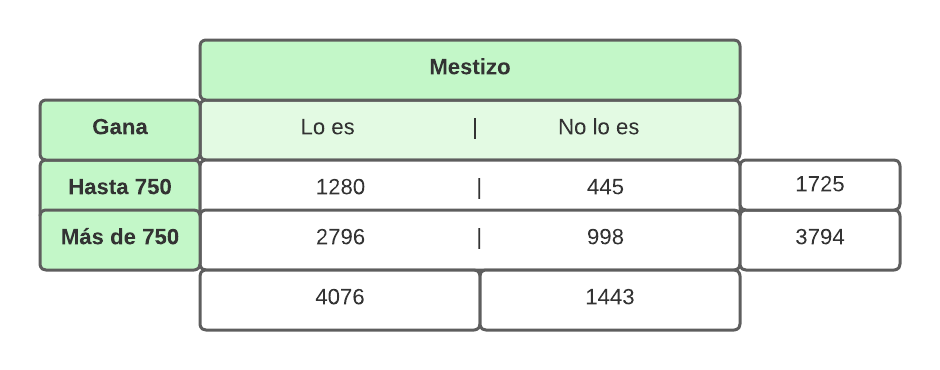

¿Cuál es la probabilidad de que un egresado tenga un primer sueldo menor o igual a los S/. 750 si es mestizo?

Al igual que el anterior, este caso es un experimento de probabilidad condicional donde el evento A es si el primer sueldo es menos de los 750 soles y nos piden saber la probabilidad de este dado el evento B (el egresado sea mestizo).

**Formula**

$$P(A|B)=P(A∩B)/P(B)$$

Espacios muestrales:  
Primer sueldo (todos los datos)

```r
table(BE1$P_SUELDO, useNA = "always")
```

```
##
## 1001 a 1500 1501 a 2500 2501 a 3500 3501 a 4500 4501 a 5500 5501 a 6500
##        1393         623         172          59          12           6
##  751 a 1000   Hasta 750 Más de 6500        <NA>
##        1524        1725           5        5045
```

Etnia (todos los datos)

```
##
##                           Aymara                           Blanco
##                              196                              761
##                          Mestizo Nativo o indigena de la amazonia
##                             7743                              100
##               Negro/mulato/zambo                          No sabe
##                              107                              332
##                             Otro                          Quechua
##                               64                             1261
##                             <NA>
##                                0
```

Probabilidades:

```
## [1] 10564
```

```
## [1] 7743
```

```
## [1] 0.732961
```

```
## [1] 0.3125566
```

```
## [1] 0.2319261
```

Se puede obserbar un 23.19% de probabilidad de que se den los dos eventos en el mismo caso (un egresado que gane menos de 750 y sea mestizo)

```
## [1] 0.2319261
```

```
## [1] 0.732961
```

```
## [1] 0.3164235
```

Respondiendo la pregunta, la probabilidad de que un egresado gane en su primer sueldo sea menor a S/750 si es mestizo es del 31.64%

Ahora toca saber si estos dos eventos son independiente o dependiente entre si.
**fórmula**
$$P(A∩B)=P(A)*P(B)$$
Si cumple entonces serán independiente y caso contrario serán dependiente

```r
round(probintM,2)
```

```
## [1] 0.23
```

```r
prIM<-ProbMest*probe750
round(prIM,2)
```

```
## [1] 0.23
```

Se puede observar que son independientes entre si.

**Ejemplo variable Mérito aplicando Bayes**

```
##
## Decimo superior Quinto Superior Tercio Superior
##           0.088           0.240           0.672
```

Solo queremos analizar las personas que han tenido orden de merito, por ello filtramos una nueva base de datos donde se eliminen a las personas sin orden de merito .

Tenemos que el 8,8% perteneció al décimo superior,el 24% perteneció al quinto superior y el 67.2% perteneció al tercio superior

```
##
## Decimo superior Quinto Superior Tercio Superior
##           0.088           0.240           0.672
```

```
##                  GENERO
## MERITO            Femenino Masculino
##   Decimo superior     0.57      0.43
##   Quinto Superior     0.62      0.38
##   Tercio Superior     0.63      0.37
```

Con la información obtenida podemos traficar nuestro árbol de probabilidad:

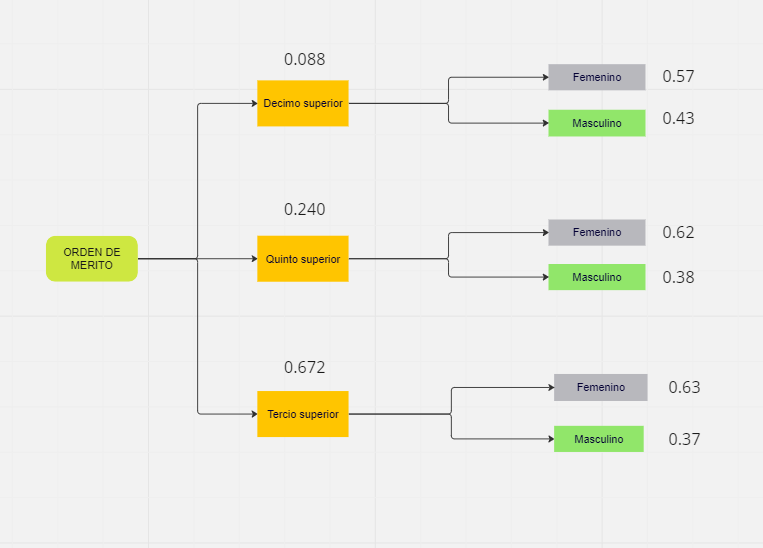

**Arbol de Probabilidad**

**Calculando la probabilidad**

Si elegimos a un egresado al azar, ¿Cual es la probabilidad de que este sea del genero masculino ?

$$P(E)=0.088*0.43+0.240*0.38+0.672*0.37 =
0.37768$$

Si elegimos a un egresado al azar, ¿Cual es la probabilidad de que este sea del genero femenino ?

$$P(E1)=0.088*0.57+0.240*0.62+0.672*0.63 =
0.62232$$
Probabilidades es 1
$$P(E) + P(E1) =0.37768 +
0.62232 ====> 1$$

## 4.3 Probabilidades Variables Discretas

**1. Distribución Binomial** Experimento aleatorio que posee solo dos posibilidades resultados: **éxito** y **fracaso**,que se repite n veces.

**2.Variable aleatoria**  
X: Número de egresados que cuentan con empleo encuestados por INEI

**3.Parámetros**

$$X~binom(p,n)$$
**Donde:**
p==>P(éxito):Seleccionar a un egresado que cuente con empleo.
n==>Total de egresados n=10564 egresados

```
##
##   No   Sí
## 2179 8385
```

```
## [1] 0.794
```

$$P(éxito)=\frac{8385}{10564}=0.794$$

```
## [1] 0.206
```

$$P(fracaso) = 1 - P(éxito)$$
$$P(fracaso) = 1 - 0.794=0.206$$

**4. Ejemplo:**

En 2014, el INEI recolectó información sobre la empleabilidad de 100 egresados en Perú. ¿Cuál es la probabilidad de que entre 60 y 80 egresados tengan trabajo?”

**formula**

$$P(X)= sum(dbinom(k,n,p))$$
k: k éxitos p: P(éxito) n: tamaño muestra

Se esperara ver una dispersión alrededor de la media de:

```
## [1] 16.59
```

```
## [1] 0.598
```

```
## [1] 0.598
```

```
## [1] 0.5983
```

Indica que hay una probabilidad del 59.83% de que entre 60 y 80 egresados tengan trabajo. En otras palabras, es más probable que entre 60 y 80 egresados tengan trabajo que no lo tengan

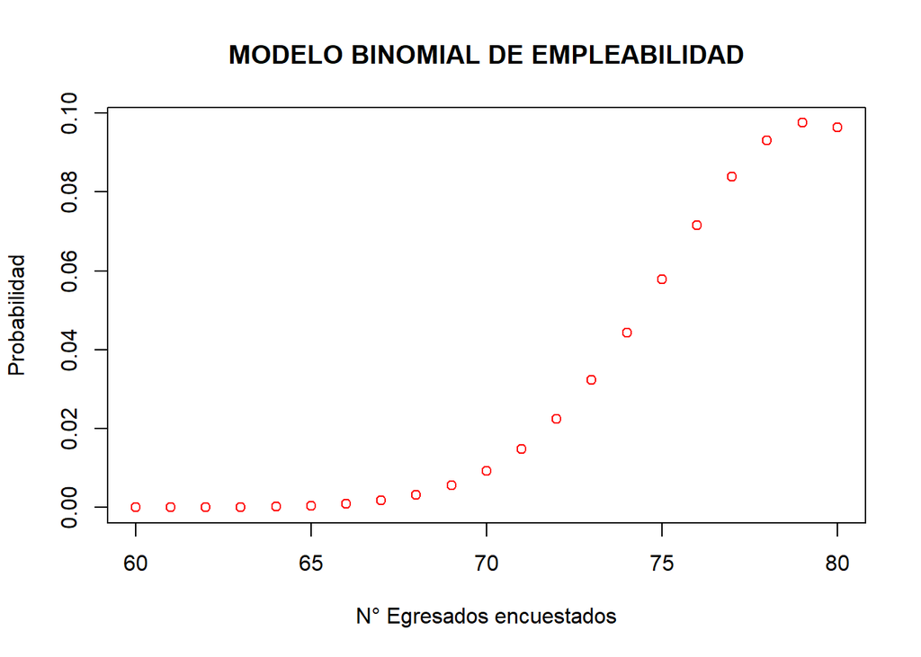

El gráfico muestra que la probabilidad de que un número determinado de egresados tengan trabajo varía en función del número de egresados.Por ejemplo, la probabilidad de que exactamente 60 egresados tengan trabajo es menor que la probabilidad de que exactamente 70 egresados tengan trabajo.

### 2 Modelo de Distribución Binomial

Se define la variable aleatoria discreta X:

$\mathbb{X}$: número de éxitos de encuestados que trabajan dependiendo de su carrera en 100 encuestados.

$r$ = 0.75

$\mathbb{X}$ ~ Bin($n$ , $r$)

$\mathbb{X}$ ~ Bin(100, 0.75)

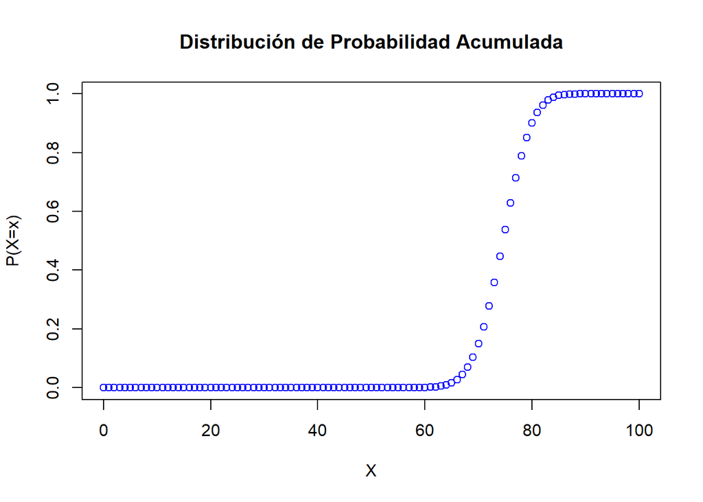

1. ¿Cual es la probabilidad de que menos 80 encuestados trabajen dependiendo de su carrera?

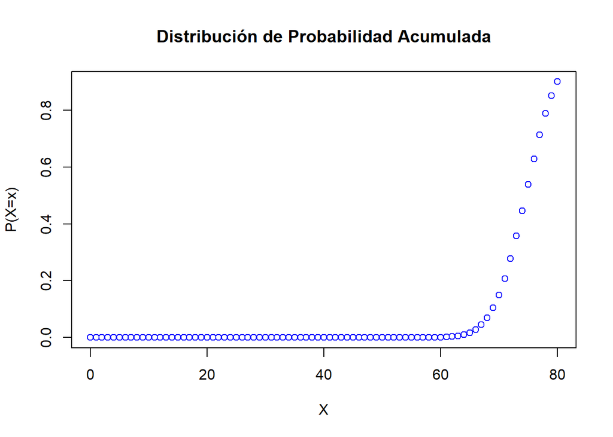

2. La probabilidad de que 50 o más encuestados trabajen dependiendo de su carrera.

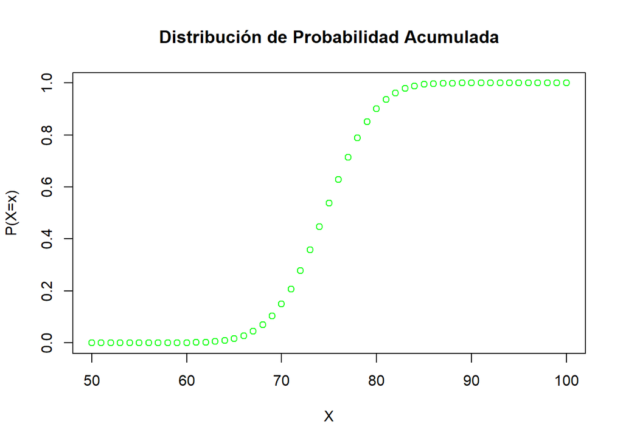

$$E(\mathbb{X}) = np = 100*(0.75) =
75$$

## 4.4 Probabilidades Variables Continuas

#### **Ingreso de ocupación Independiente**

Primero, se hace el histograma de la variable junto al gráfico de densidad

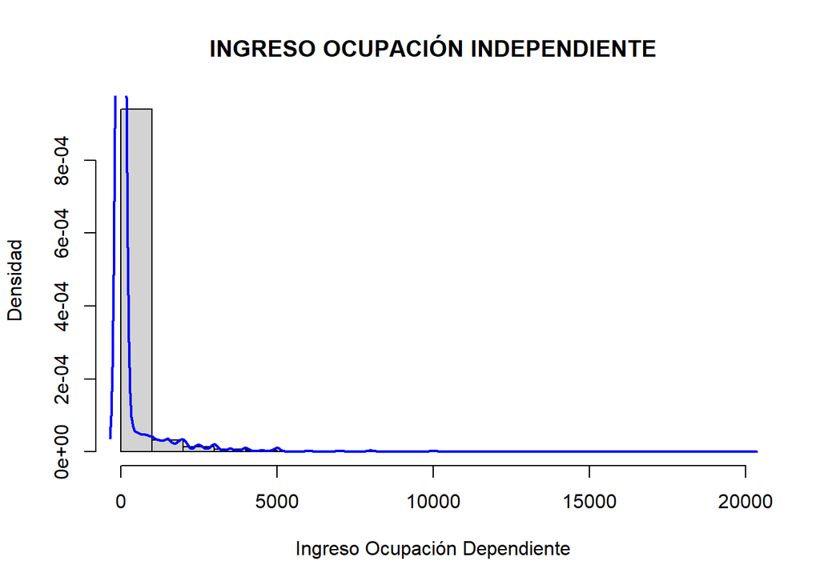

Se puede observar claramente que lo que mas lo puede representar es una forma exponencial por lo que se trabajará y tomará con este modelo.

Con esto se puede hallar el valor de lambda (λ)

```
## [1] 0.005100124
```

Con lambda se sacara una proyección de densidad teórica si fuera exponencial con lo que podemos comparar con el real para ver si es así.

Comparación de densidades (Tener en cuenta que se esta tomando una parte de todos los datos para tener mayor exactitud en la proyección teórica):

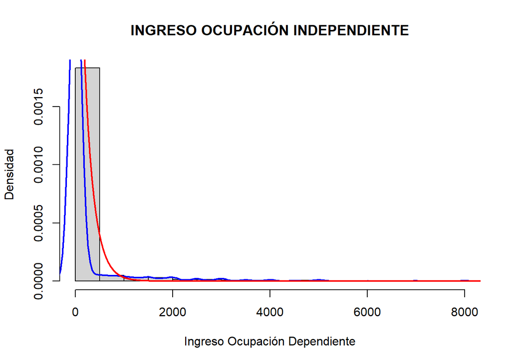

Nos pide saber la probabilidad de que uno de los egresados tenga un ingreso de este tipo nulo, osea igual a S/ 0 (evento A).

Primero habrá que sacar el conteo del espacio muestral del evento A con el total.

```
## [1] 9364
```

```
## [1] 10564
```

```
## [1] 0.8864067
```

Se hallo que la probabilidad de que un egresado no presente ingresos generados por una ocupación suya de manera independiente es del 88.64%.  
**Experimento**  
Seleccionar a los egresado del estudio de la la situación laboral de los egresados en el Perú en el año 2014 y observar su ingreso de ocupación dependiente.

hacer el histograma y el gráfico de densidad

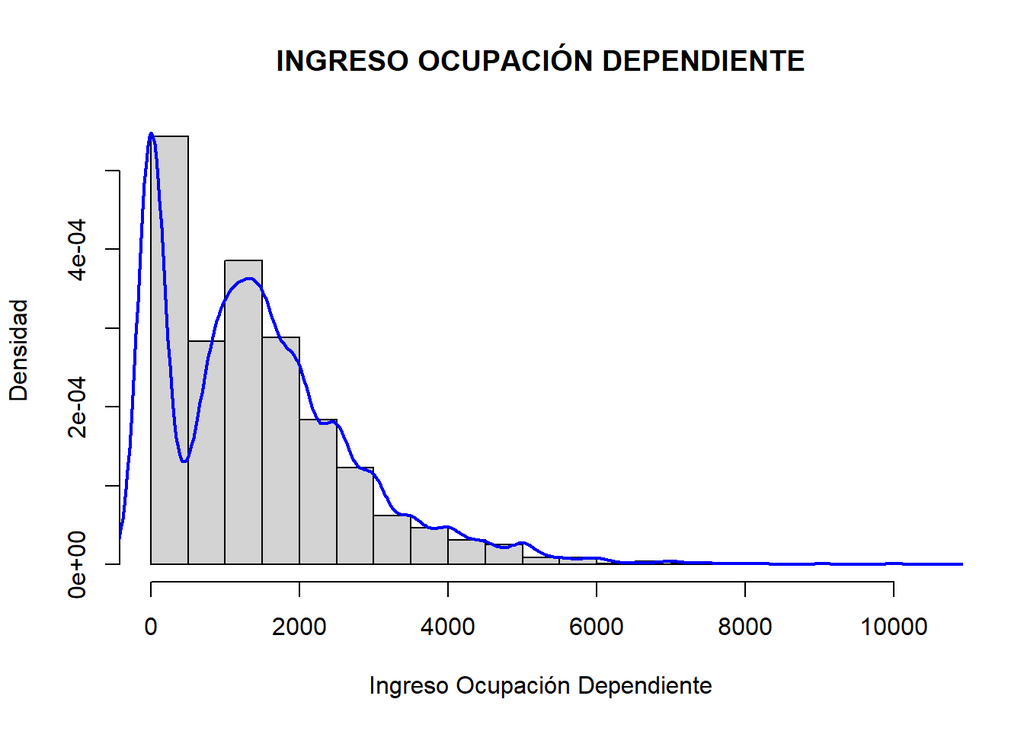

Hallar el valor de lambda (λ)

```
## [1] 0.0006839822
```

Proyección de densidad teórica si fuera exponencial y comparar con el real.

Comparación de densidades:

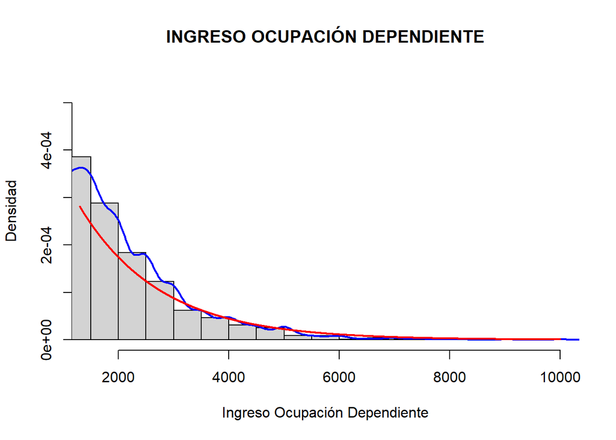

Se puede observa una gran similitud en el comportamiento de las dos densidades por lo que podemos validar su comportamiento exponencial con lo que podemos saber su distribución exponencial: X~Exp(λ) P[X=x]=λ*e^-λx

**Espacio_Resultados**  
- sueldos que varían del 0 al 10000

```
## [1] 0
```

```
## [1] 10000
```

[output not shown]

[output cut: 92 more lines]

**Identificar_eventos**

Elegimos ingresos aleatorios para comparar  
Nuestros eventos serán:  
Personas que tienen_ingreso 0  
Personas que tienen_ingreso 2500  
Personas que tienen_ingreso 3000  
Personas que tienen_ingreso 5000  
Personas que tienen_ingreso 7500  
Personas que tienen_ingreso 10000

**Calculando_la_probabilidad**

```
## [1] 0.2296268
```

```
## [1] 0.05140899
```

```
## [1] 0.02894136
```

```
## [1] 0.007616146
```

```
## [1] 0.0003808073
```

```
## [1] 0.0007616146
```

**Conclusión 1**

De la comparación de probabilidades de los ingresos de ocupación dependiente, podemos decir que hay aproximadamente un 23% de personas que tiene un ingreso 0, es decir no trabajan, mientras que las probabilidades de los egresados que tienen ingresos de ocupación dependiente son muy bajas. Podemos observar que la diferencia de probabilidad empírica de el mínimo ingreso es con el máximo ingreso de un egreso es notable, esto puede deberse a varios factores como la experiencia laboral de un egresado, la demanda de su carrera, habilidades del egresado.

**Conclusión 2**

Relación entre la carrera estudiada y la empleabilidad: Según los datos analizados, se puede concluir que existe una marcada tendencia entre los egresados del 2014 en Perú a encontrar empleo relacionado con la carrera que estudiaron. Más del 80% de los encuestados que están trabajando se encuentran en ocupaciones vinculadas a su formación universitaria. Esto indica que el estudio universitario y lo aprendido durante la carrera tienen relevancia en el ámbito laboral, lo que aumenta las posibilidades de empleabilidad para los egresados.

**Conclusión 3**

Tiempo para conseguir el primer trabajo: Aunque se reconoce la presencia de un sesgo de muestreo debido a la falta de especificidad en los datos, se puede observar que los egresados que buscan trabajo después de finalizar sus estudios universitarios tienden a encontrar empleo en un tiempo relativamente corto. Casi la mitad de los egresados (47.25%) logra conseguir un trabajo en menos de un mes, y otro grupo significativo (34.49%) lo consigue en un periodo de 1 a 3 meses. Estos resultados indican que, en general, los egresados universitarios del 2014 en Perú tienen buenas oportunidades de inserción laboral en el mercado.